# K-means clustering & Schools.csv

E. McLaren. "On my honor, as a student, I have neither given nor received unauthorized aid on this academic work."

# Import packages & data (schools.csv)

```python
#import packages
import numpy as np
import pandas as pd
import matplotlib.pyplot as plt
import seaborn as sns
%matplotlib inline
import plotly.express as px
from scipy import stats
from scipy.stats import mannwhitneyu #using scipy package

from sklearn.cluster import KMeans

from sklearn.cluster import AgglomerativeClustering
from sklearn.metrics import pairwise_distances

# import DecisionTreeClassifier

from sklearn.tree import DecisionTreeClassifier
from sklearn import metrics
from sklearn import tree

# import Random Forest Classifier
from sklearn.ensemble import RandomForestClassifier

#import clustering models
from sklearn.cluster import KMeans
from sklearn.cluster import AgglomerativeClustering
from sklearn.cluster import ward_tree
from scipy.cluster.hierarchy import dendrogram, linkage, ward

#pip install scikit-plot (optional)
import scikitplot as skplt

import pingouin as pg

import warnings
warnings.filterwarnings("ignore")
```

```python
# load schools.csv
df = pd.read_csv('data/schools.csv')
df.head()
```

|  | School_Code | School_Name | Pct_First_Language_Not_English | Pct_English_Language_Learner | Pct_Students_With_Disabilities | Pct_High_Needs | Pct_Economically_Disadvantaged | Pct_African_American | Pct_Asian | Pct_Hispanic | Pct_White | Pct_Native_American | Pct_Native_Hawaiian_Pacific_Isla | Pct_MultiRace_NonHispanic | Pct_Males | Pct_Females | Average_Class_Size |
| --- | --- | --- | --- | --- | --- | --- | --- | --- | --- | --- | --- | --- | --- | --- | --- | --- | --- |
| 0 | 10505.0 | Abington High | 5.3 | 2.4 | 9.7 | 28.8 | 21.5 | 2.2 | 1.5 | 9.1 | 85.8 | 0.2 | 0.2 | 0.9 | 45.6 | 54.4 | 15.8 |
| 1 | 10003.0 | Beaver Brook Elementary School | 10.5 | 7.2 | 13.3 | 37.1 | 23.3 | 1.9 | 1.9 | 6.7 | 88.4 | 0.5 | 0.2 | 0.3 | 50.2 | 49.8 | 24.6 |
| 2 | 10002.0 | Center Elementary School | 12.8 | 3.0 | 21.2 | 34.0 | 16.3 | 3.9 | 3.0 | 8.4 | 84.7 | 0.0 | 0.0 | 0.0 | 54.2 | 45.8 | 14.6 |
| 3 | 10405.0 | Frolio Middle School | 5.5 | 1.8 | 13.1 | 30.8 | 21.6 | 2.4 | 1.8 | 6.1 | 89.3 | 0.0 | 0.0 | 0.3 | 53.4 | 46.6 | 21.1 |
| 4 | 10015.0 | Woodsdale Elementary School | 5.9 | 2.0 | 10.8 | 30.6 | 22.7 | 2.0 | 1.4 | 4.2 | 92.1 | 0.0 | 0.0 | 0.3 | 50.7 | 49.3 | 30.4 |

# Data Preparation

- Drop two columns ('School_Code', 'School_Name')
- Handle missing values

```python
#drop School_Code and School_Name columns
df_new = df.drop(['School_Code', 'School_Name'], axis =1)
df_new.head()
```

|  | Pct_First_Language_Not_English | Pct_English_Language_Learner | Pct_Students_With_Disabilities | Pct_High_Needs | Pct_Economically_Disadvantaged | Pct_African_American | Pct_Asian | Pct_Hispanic | Pct_White | Pct_Native_American | Pct_Native_Hawaiian_Pacific_Isla | Pct_MultiRace_NonHispanic | Pct_Males | Pct_Females | Average_Class_Size |
| --- | --- | --- | --- | --- | --- | --- | --- | --- | --- | --- | --- | --- | --- | --- | --- |
| 0 | 5.3 | 2.4 | 9.7 | 28.8 | 21.5 | 2.2 | 1.5 | 9.1 | 85.8 | 0.2 | 0.2 | 0.9 | 45.6 | 54.4 | 15.8 |
| 1 | 10.5 | 7.2 | 13.3 | 37.1 | 23.3 | 1.9 | 1.9 | 6.7 | 88.4 | 0.5 | 0.2 | 0.3 | 50.2 | 49.8 | 24.6 |
| 2 | 12.8 | 3.0 | 21.2 | 34.0 | 16.3 | 3.9 | 3.0 | 8.4 | 84.7 | 0.0 | 0.0 | 0.0 | 54.2 | 45.8 | 14.6 |
| 3 | 5.5 | 1.8 | 13.1 | 30.8 | 21.6 | 2.4 | 1.8 | 6.1 | 89.3 | 0.0 | 0.0 | 0.3 | 53.4 | 46.6 | 21.1 |
| 4 | 5.9 | 2.0 | 10.8 | 30.6 | 22.7 | 2.0 | 1.4 | 4.2 | 92.1 | 0.0 | 0.0 | 0.3 | 50.7 | 49.3 | 30.4 |

```python
#find missing values
df_new.isnull().sum().sort_values(ascending=False)
```

```
Average_Class_Size                  38
Pct_Females                         11
Pct_Males                           11
Pct_MultiRace_NonHispanic           11
Pct_Native_Hawaiian_Pacific_Isla    11
Pct_Native_American                 11
Pct_White                           11
Pct_Hispanic                        11
Pct_Asian                           11
Pct_African_American                11
Pct_Economically_Disadvantaged      11
Pct_High_Needs                      11
Pct_Students_With_Disabilities      11
Pct_English_Language_Learner        11
Pct_First_Language_Not_English      11
dtype: int64
```

```python
# check data set statistics
df_new.describe()
```

|  | Pct_First_Language_Not_English | Pct_English_Language_Learner | Pct_Students_With_Disabilities | Pct_High_Needs | Pct_Economically_Disadvantaged | Pct_African_American | Pct_Asian | Pct_Hispanic | Pct_White | Pct_Native_American | Pct_Native_Hawaiian_Pacific_Isla | Pct_MultiRace_NonHispanic | Pct_Males | Pct_Females | Average_Class_Size |
| --- | --- | --- | --- | --- | --- | --- | --- | --- | --- | --- | --- | --- | --- | --- | --- |
| count | 1850.00000 | 1850.000000 | 1850.000000 | 1850.000000 | 1850.000000 | 1850.000000 | 1850.000000 | 1850.000000 | 1850.000000 | 1850.000000 | 1850.000000 | 1850.000000 | 1850.000000 | 1850.000000 | 1823.000000 |
| mean | 18.54827 | 9.548432 | 18.223676 | 46.616216 | 31.816649 | 8.699459 | 6.050919 | 18.996649 | 62.326486 | 0.233459 | 0.098000 | 3.596595 | 51.899405 | 48.095135 | 18.320570 |
| std | 20.03104 | 13.163096 | 11.462500 | 22.966461 | 22.409908 | 13.698280 | 8.763984 | 22.575734 | 29.562086 | 0.501732 | 0.285813 | 2.420830 | 5.121577 | 5.122469 | 3.966979 |
| min | 0.00000 | 0.000000 | 0.000000 | 0.000000 | 0.000000 | 0.000000 | 0.000000 | 0.000000 | 0.000000 | 0.000000 | 0.000000 | 0.000000 | 24.000000 | 0.000000 | 2.000000 |
| 25% | 3.20000 | 0.900000 | 12.900000 | 27.400000 | 12.825000 | 1.400000 | 1.200000 | 4.000000 | 41.000000 | 0.000000 | 0.000000 | 1.900000 | 49.400000 | 46.400000 | 16.300000 |
| 50% | 10.50000 | 3.600000 | 16.100000 | 41.200000 | 25.900000 | 3.300000 | 2.600000 | 8.200000 | 73.200000 | 0.000000 | 0.000000 | 3.200000 | 51.400000 | 48.600000 | 18.600000 |
| 75% | 27.90000 | 13.200000 | 20.000000 | 64.975000 | 47.800000 | 8.700000 | 6.900000 | 27.300000 | 86.600000 | 0.300000 | 0.100000 | 4.775000 | 53.600000 | 50.600000 | 20.800000 |
| max | 100.00000 | 82.900000 | 100.000000 | 100.000000 | 94.400000 | 86.900000 | 73.700000 | 98.000000 | 100.000000 | 8.000000 | 6.100000 | 17.400000 | 100.000000 | 76.000000 | 41.100000 |

```python
#drop missing values
df_new = df_new.dropna()
```

```python
#verify missing values are dropped
df_new.isnull().sum()
```

```
Pct_First_Language_Not_English      0
Pct_English_Language_Learner        0
Pct_Students_With_Disabilities      0
Pct_High_Needs                      0
Pct_Economically_Disadvantaged      0
Pct_African_American                0
Pct_Asian                           0
Pct_Hispanic                        0
Pct_White                           0
Pct_Native_American                 0
Pct_Native_Hawaiian_Pacific_Isla    0
Pct_MultiRace_NonHispanic           0
Pct_Males                           0
Pct_Females                         0
Average_Class_Size                  0
dtype: int64
```

```python
#check data set length
len(df_new)
```

```
1823
```

```python
#reset index for data set since missing values were removed
df_new = df_new.reset_index(drop=True)
```

# Perform variance analysis

- Explain why data normalization is necessary

```python
# variance test
df_new.var()
```

```
Pct_First_Language_Not_English      404.383426
Pct_English_Language_Learner        174.065427
Pct_Students_With_Disabilities      124.524392
Pct_High_Needs                      527.478833
Pct_Economically_Disadvantaged      504.583759
Pct_African_American                185.179021
Pct_Asian                            76.950470
Pct_Hispanic                        512.353186
Pct_White                           877.534691
Pct_Native_American                   0.247437
Pct_Native_Hawaiian_Pacific_Isla      0.079760
Pct_MultiRace_NonHispanic             5.876525
Pct_Males                            25.421004
Pct_Females                          25.430093
Average_Class_Size                   15.736926
dtype: float64
```

Since there is a very low variance for both the Pct_Native_American (0.247437) and Pct_Native_Hawaiian_Pacific_Isla (0.079760), in comparison to variables like Pct_First_Language_Not_English (404.383426) and Pct_White (877.534691), then these smaller variance variables may not appear to have as much an influence in the cluster analysis even though they could have more importance. It is necessary to normalize these so these variables can be compared more accurately in the scope of determining clusters fairly.

# Normalize data & Check variance again

```python
#normalize data
df1 = (df_new - df_new.mean()) / (df_new.max() - df_new.min())
df1.head()
```

|  | Pct_First_Language_Not_English | Pct_English_Language_Learner | Pct_Students_With_Disabilities | Pct_High_Needs | Pct_Economically_Disadvantaged | Pct_African_American | Pct_Asian | Pct_Hispanic | Pct_White | Pct_Native_American | Pct_Native_Hawaiian_Pacific_Isla | Pct_MultiRace_NonHispanic | Pct_Males | Pct_Females | Average_Class_Size |
| --- | --- | --- | --- | --- | --- | --- | --- | --- | --- | --- | --- | --- | --- | --- | --- |
| 0 | -0.13276 | -0.086390 | -0.084592 | -0.177116 | -0.108704 | -0.080131 | -0.061879 | -0.100950 | 0.23435 | -0.003895 | 0.016897 | -0.155412 | -0.082948 | 0.083022 | -0.064465 |
| 1 | -0.08076 | -0.028489 | -0.048592 | -0.094116 | -0.089636 | -0.083857 | -0.056452 | -0.125440 | 0.26035 | 0.033605 | 0.016897 | -0.189895 | -0.022422 | 0.022495 | 0.160599 |
| 2 | -0.05776 | -0.079152 | 0.030408 | -0.125116 | -0.163789 | -0.059013 | -0.041527 | -0.108093 | 0.22335 | -0.028895 | -0.015890 | -0.207136 | 0.030210 | -0.030136 | -0.095155 |
| 3 | -0.13076 | -0.093627 | -0.050592 | -0.157116 | -0.107645 | -0.077646 | -0.057809 | -0.131563 | 0.26935 | -0.028895 | -0.015890 | -0.189895 | 0.019683 | -0.019610 | 0.071085 |
| 4 | -0.12676 | -0.091215 | -0.073592 | -0.159116 | -0.095992 | -0.082615 | -0.063236 | -0.150950 | 0.29735 | -0.028895 | -0.015890 | -0.189895 | -0.015843 | 0.015917 | 0.308937 |

```python
# 2nd variance test
df1.var()
```

```
Pct_First_Language_Not_English      0.040438
Pct_English_Language_Learner        0.025328
Pct_Students_With_Disabilities      0.012452
Pct_High_Needs                      0.052748
Pct_Economically_Disadvantaged      0.056623
Pct_African_American                0.028576
Pct_Asian                           0.014167
Pct_Hispanic                        0.053348
Pct_White                           0.087753
Pct_Native_American                 0.003866
Pct_Native_Hawaiian_Pacific_Isla    0.002144
Pct_MultiRace_NonHispanic           0.019410
Pct_Males                           0.004401
Pct_Females                         0.004403
Average_Class_Size                  0.010294
dtype: float64
```

As you can see from the variance test, the variables have been normalized so they will provide more accurate representations of the data set when conducting a clustering analysis.

# Clustering analysis (k = 2): Include "random_state=0"

```python
# clustering analysis using k-means

k_means = KMeans(init='k-means++', n_clusters=2, random_state=0)
```

```python
#fit data into model
k_means.fit(df1)
```

```
KMeans(algorithm='auto', copy_x=True, init='k-means++', max_iter=300,
       n_clusters=2, n_init=10, n_jobs=None, precompute_distances='auto',
       random_state=0, tol=0.0001, verbose=0)
```

```python
# cluster labels
k_means.labels_
```

```
array([0, 0, 0, ..., 1, 0, 1], dtype=int32)
```

```python
# find out cluster centers
k_means.cluster_centers_
```

```
array([[-0.09703442, -0.07235229, -0.01278394, -0.12068386, -0.1208956 ,
        -0.06245258, -0.00170108, -0.11795934,  0.16568047,  0.00054548,
        -0.00067371,  0.00830343, -0.00573112,  0.00571126, -0.00107118],
       [ 0.23799161,  0.17745496,  0.03135454,  0.29599545,  0.29651478,
         0.1531744 ,  0.00417215,  0.28931316, -0.40635647, -0.00133786,
         0.00165237, -0.02036542,  0.01405644, -0.01400774,  0.00262724]])
```

```python
# convert cluster labels to dataframe
c = pd.DataFrame(k_means.labels_, columns = ['cluster'])
c.head()
```

|  | cluster |
| --- | --- |
| 0 | 0 |
| 1 | 0 |
| 2 | 0 |
| 3 | 0 |
| 4 | 0 |

```python
# reset index for cluster set
c = c.reset_index(drop=True)
```

```python
#verify lengths of both data set are equal before joining
len(df1)
```

```
1823
```

```python
#verify lengths of both data set are equal before joining
len(c)
```

```
1823
```

```python
#join normalized data and cluster data
df2 = df1.join(c)
df2.head()
```

|  | Pct_First_Language_Not_English | Pct_English_Language_Learner | Pct_Students_With_Disabilities | Pct_High_Needs | Pct_Economically_Disadvantaged | Pct_African_American | Pct_Asian | Pct_Hispanic | Pct_White | Pct_Native_American | Pct_Native_Hawaiian_Pacific_Isla | Pct_MultiRace_NonHispanic | Pct_Males | Pct_Females | Average_Class_Size | cluster |
| --- | --- | --- | --- | --- | --- | --- | --- | --- | --- | --- | --- | --- | --- | --- | --- | --- |
| 0 | -0.13276 | -0.086390 | -0.084592 | -0.177116 | -0.108704 | -0.080131 | -0.061879 | -0.100950 | 0.23435 | -0.003895 | 0.016897 | -0.155412 | -0.082948 | 0.083022 | -0.064465 | 0 |
| 1 | -0.08076 | -0.028489 | -0.048592 | -0.094116 | -0.089636 | -0.083857 | -0.056452 | -0.125440 | 0.26035 | 0.033605 | 0.016897 | -0.189895 | -0.022422 | 0.022495 | 0.160599 | 0 |
| 2 | -0.05776 | -0.079152 | 0.030408 | -0.125116 | -0.163789 | -0.059013 | -0.041527 | -0.108093 | 0.22335 | -0.028895 | -0.015890 | -0.207136 | 0.030210 | -0.030136 | -0.095155 | 0 |
| 3 | -0.13076 | -0.093627 | -0.050592 | -0.157116 | -0.107645 | -0.077646 | -0.057809 | -0.131563 | 0.26935 | -0.028895 | -0.015890 | -0.189895 | 0.019683 | -0.019610 | 0.071085 | 0 |
| 4 | -0.12676 | -0.091215 | -0.073592 | -0.159116 | -0.095992 | -0.082615 | -0.063236 | -0.150950 | 0.29735 | -0.028895 | -0.015890 | -0.189895 | -0.015843 | 0.015917 | 0.308937 | 0 |

```python
#group new data set by cluster and get average value for each variable
df2.groupby(['cluster']).mean()
```

| cluster | Pct_First_Language_Not_English | Pct_English_Language_Learner | Pct_Students_With_Disabilities | Pct_High_Needs | Pct_Economically_Disadvantaged | Pct_African_American | Pct_Asian | Pct_Hispanic | Pct_White | Pct_Native_American | Pct_Native_Hawaiian_Pacific_Isla | Pct_MultiRace_NonHispanic | Pct_Males | Pct_Females | Average_Class_Size |
| --- | --- | --- | --- | --- | --- | --- | --- | --- | --- | --- | --- | --- | --- | --- | --- |
| 0 | -0.097034 | -0.072352 | -0.012784 | -0.120684 | -0.120896 | -0.062453 | -0.001701 | -0.117959 | 0.165680 | 0.000545 | -0.000674 | 0.008303 | -0.005731 | 0.005711 | -0.001071 |
| 1 | 0.237992 | 0.177455 | 0.031355 | 0.295995 | 0.296515 | 0.153174 | 0.004172 | 0.289313 | -0.406356 | -0.001338 | 0.001652 | -0.020365 | 0.014056 | -0.014008 | 0.002627 |

# Interpretation of Clustering Analysis

- When you answer the following questions below, use the original data (not the normalized data) for better interpretability

## How many observations are there in cluster 1 and cluster 2?

```python
#join original data set and cluster set
df3 = df_new.join(c)
df3.head()
```

|  | Pct_First_Language_Not_English | Pct_English_Language_Learner | Pct_Students_With_Disabilities | Pct_High_Needs | Pct_Economically_Disadvantaged | Pct_African_American | Pct_Asian | Pct_Hispanic | Pct_White | Pct_Native_American | Pct_Native_Hawaiian_Pacific_Isla | Pct_MultiRace_NonHispanic | Pct_Males | Pct_Females | Average_Class_Size | cluster |
| --- | --- | --- | --- | --- | --- | --- | --- | --- | --- | --- | --- | --- | --- | --- | --- | --- |
| 0 | 5.3 | 2.4 | 9.7 | 28.8 | 21.5 | 2.2 | 1.5 | 9.1 | 85.8 | 0.2 | 0.2 | 0.9 | 45.6 | 54.4 | 15.8 | 0 |
| 1 | 10.5 | 7.2 | 13.3 | 37.1 | 23.3 | 1.9 | 1.9 | 6.7 | 88.4 | 0.5 | 0.2 | 0.3 | 50.2 | 49.8 | 24.6 | 0 |
| 2 | 12.8 | 3.0 | 21.2 | 34.0 | 16.3 | 3.9 | 3.0 | 8.4 | 84.7 | 0.0 | 0.0 | 0.0 | 54.2 | 45.8 | 14.6 | 0 |
| 3 | 5.5 | 1.8 | 13.1 | 30.8 | 21.6 | 2.4 | 1.8 | 6.1 | 89.3 | 0.0 | 0.0 | 0.3 | 53.4 | 46.6 | 21.1 | 0 |
| 4 | 5.9 | 2.0 | 10.8 | 30.6 | 22.7 | 2.0 | 1.4 | 4.2 | 92.1 | 0.0 | 0.0 | 0.3 | 50.7 | 49.3 | 30.4 | 0 |

```python
#verify there are no error with missing values
df3.isnull().sum()
```

```
Pct_First_Language_Not_English      0
Pct_English_Language_Learner        0
Pct_Students_With_Disabilities      0
Pct_High_Needs                      0
Pct_Economically_Disadvantaged      0
Pct_African_American                0
Pct_Asian                           0
Pct_Hispanic                        0
Pct_White                           0
Pct_Native_American                 0
Pct_Native_Hawaiian_Pacific_Isla    0
Pct_MultiRace_NonHispanic           0
Pct_Males                           0
Pct_Females                         0
Average_Class_Size                  0
cluster                             0
dtype: int64
```

```python
#check how many observations in each cluster
df3.groupby('cluster').size()
```

```
cluster
0    1295
1     528
dtype: int64
```

## The mean values of each cluster in terms of different variables (e.g., Pct_High_Needs)

```python
#The mean values of each cluster for Pct_High_Needs
df3.groupby('cluster')['Pct_High_Needs'].mean()
```

```
cluster
0    34.443243
1    76.111174
Name: Pct_High_Needs, dtype: float64
```

```python
#The mean values of each cluster for Pct_First_Language_Not_English
df3.groupby('cluster')['Pct_First_Language_Not_English'].mean()
```

```
cluster
0     8.872587
1    42.375189
Name: Pct_First_Language_Not_English, dtype: float64
```

```python
#The mean values of each cluster for Pct_English_Language_Learner
df3.groupby('cluster')['Pct_English_Language_Learner'].mean()
```

```
cluster
0     3.563707
1    24.272727
Name: Pct_English_Language_Learner, dtype: float64
```

```python
#The mean values of each cluster for Pct_Students_With_Disabilities
df3.groupby('cluster')['Pct_Students_With_Disabilities'].mean()
```

```
cluster
0    16.880849
1    21.294697
Name: Pct_Students_With_Disabilities, dtype: float64
```

```python
#The mean values of each cluster for Pct_Economically_Disadvantaged
df3.groupby('cluster')['Pct_Economically_Disadvantaged'].mean()
```

```
cluster
0    20.349112
1    59.752652
Name: Pct_Economically_Disadvantaged, dtype: float64
```

```python
#The mean values of each cluster for Pct_African_American
df3.groupby('cluster')['Pct_African_American'].mean()
```

```
cluster
0     3.623089
1    20.981061
Name: Pct_African_American, dtype: float64
```

```python
#The mean values of each cluster for Pct_Asian
df3.groupby('cluster')['Pct_Asian'].mean()
```

```
cluster
0    5.935135
1    6.367992
Name: Pct_Asian, dtype: float64
```

```python
#The mean values of each cluster for Pct_Hispanic
df3.groupby('cluster')['Pct_Hispanic'].mean()
```

```
cluster
0     7.433127
1    47.345833
Name: Pct_Hispanic, dtype: float64
```

```python
#The mean values of each cluster for Pct_White
df3.groupby('cluster')['Pct_White'].mean()
```

```
cluster
0    78.933050
1    21.729356
Name: Pct_White, dtype: float64
```

```python
#The mean values of each cluster for Pct_Native_American
df3.groupby('cluster')['Pct_Native_American'].mean()
```

```
cluster
0    0.235521
1    0.220455
Name: Pct_Native_American, dtype: float64
```

```python
#The mean values of each cluster for Pct_Native_Hawaiian_Pacific_Isla
df3.groupby('cluster')['Pct_Native_Hawaiian_Pacific_Isla'].mean()
```

```
cluster
0    0.092819
1    0.107008
Name: Pct_Native_Hawaiian_Pacific_Isla, dtype: float64
```

```python
#The mean values of each cluster for Pct_MultiRace_NonHispanic
df3.groupby('cluster')['Pct_MultiRace_NonHispanic'].mean()
```

```
cluster
0    3.748649
1    3.249811
Name: Pct_MultiRace_NonHispanic, dtype: float64
```

```python
#The mean values of each cluster for Pct_Males
df3.groupby('cluster')['Pct_Males'].mean()
```

```
cluster
0    51.468494
1    52.972348
Name: Pct_Males, dtype: float64
```

```python
#The mean values of each cluster for Pct_Females
df3.groupby('cluster')['Pct_Females'].mean()
```

```
cluster
0    48.524402
1    47.025758
Name: Pct_Females, dtype: float64
```

```python
#The mean values of each cluster for Average_Class_Size
df3.groupby('cluster')['Average_Class_Size'].mean()
```

```
cluster
0    18.278687
1    18.423295
Name: Average_Class_Size, dtype: float64
```

## What is the profile of each cluster?

**Cluster 1:**

- Pct_High_Needs: This cluster has a lower percentage of high needs students with an average of 34.44%.
- Pct_First_Language_Not_English: This cluster has a lower percentage of students whose first language isn't English with an average of 8.87%.
- Pct_English_Language_Learner: This cluster has a lower percentage of students who are learning English with an average of 3.56%.
- Pct_Students_With_Disabilities: This cluster has a lower percentage of students with disabilities with an average of 16.88%.
- Pct_Economically_Disadvantaged: This cluster has a lower percentage of students who are economically disadvantaged with an average of 20.35%.
- Pct_African_American: This cluster has a lower percentage of African-American students with an average of 3.62%.
- Pct_Asian: This cluster has a lower percentage of Asian students with an average of 5.94%.
- Pct_Hispanic: This cluster has a lower percentage of Hispanic students with an average of 7.43%.
- Pct_White: This cluster has a higher percentage of White students with an average of 78.93%.
- Pct_Native_American: This cluster has a low percentage of Native American students with an average of 0.23%.
- Pct_Native_Hawaiian_Pacific_Isla: This cluster has a low percentage of Native Hawaiian and Pacific Islander students with an average of 0.09%.
- Pct_MultiRace_NonHispanic: This cluster has a low percentage of Multi-race and Non-Hispanic students with an average of 3.75%.
- Pct_Males: This cluster has a slightly higher percentage of males than females with and average of 51.47%.
- Pct_Females: This cluster has a slightly lower percentage of females than males with and average of 48.52%.
- Average_Class_Size: This cluster has an average class size of 18.28 students, which is very slightly lower than that of cluster 2.

Based on these findings, this cluster 1 could be described as having less diversity than that of cluster 2. This cluster also has less students with disabilities, economic disadvantages, and another language than English as their first language. There was little difference in class size and male to female ratios between the two clusters.

**Cluster 2:**

Based on these findings, this cluster 2 could be described as having more diversity than that of cluster 1. This cluster also has more students with disabilities, economic disadvantages, and another language than English as their first language. There was little difference in class size and male to female ratios between the two clusters.

## The mean values for"Pct_African_American" in each cluster. Also visualize it.

```python
# mean values for"Pct_African_American" in each cluster
df3.groupby('cluster')['Pct_African_American'].mean()
```

```
cluster
0     3.623089
1    20.981061
Name: Pct_African_American, dtype: float64
```

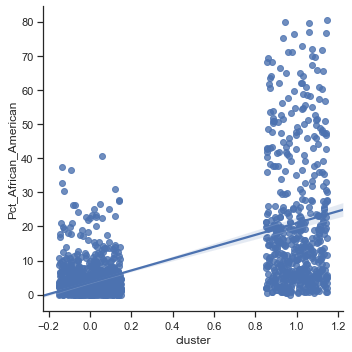

```python
#mean values for"Pct_African_American" in each cluster visual
sns.lmplot("cluster", "Pct_African_American", df3, x_jitter=.15, y_jitter=.15);
```

## Which of the following statements is TRUE?

a. Schools in cluster 1, on average, have a higher percentage of African American students?

b. Schools in cluster 2, on average, have a higher percentage of African American students?

Statement b is true, as shown by the data presented above. Cluster 1 only has an average of 3.62%, while cluster 2 has an average of 20.98% African-American students.

## The mean values for "Pct_First_Language_Not_English" in each cluster. Also visualize it.

```python
#The mean values for "Pct_First_Language_Not_English" in each cluster
df3.groupby('cluster')['Pct_First_Language_Not_English'].mean()
```

```
cluster
0     8.872587
1    42.375189
Name: Pct_First_Language_Not_English, dtype: float64
```

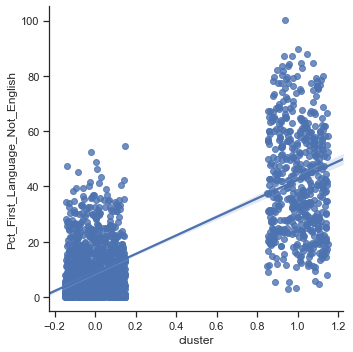

```python
#The mean values for "Pct_First_Language_Not_English" in each cluster visual
sns.lmplot("cluster", "Pct_First_Language_Not_English", df3, x_jitter=.15, y_jitter=.15);
```

## Which cluster has a higher percentage of economically disadvantaged students **__**

```python
#The mean values for Pct_Economically_Disadvantaged in each cluster
df3.groupby('cluster')['Pct_Economically_Disadvantaged'].mean()
```

```
cluster
0    20.349112
1    59.752652
Name: Pct_Economically_Disadvantaged, dtype: float64
```

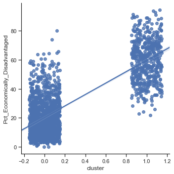

```python
#The mean values for Pct_Economically_Disadvantaged in each cluster visual
sns.lmplot("cluster", "Pct_Economically_Disadvantaged", df3, x_jitter=.15, y_jitter=.15);
```

Cluster 2 has a significantly higher average percentage of economically disadvantaged students with an average of 59.75% compared to Cluster 1 which only has an average of 20.35%.

# Build Decision Tree model (use the original data, not the normalizaed data)

- Do model building using decision tree algorithm
- Visualize and embed decision tree (in pdf) in Jupyter Notebook

```python
# set X and y

y = df3['cluster'].values
X = df3.drop(['cluster'], axis=1)
```

```python
#verify cluster column was removed
X.head()
```

|  | Pct_First_Language_Not_English | Pct_English_Language_Learner | Pct_Students_With_Disabilities | Pct_High_Needs | Pct_Economically_Disadvantaged | Pct_African_American | Pct_Asian | Pct_Hispanic | Pct_White | Pct_Native_American | Pct_Native_Hawaiian_Pacific_Isla | Pct_MultiRace_NonHispanic | Pct_Males | Pct_Females | Average_Class_Size |
| --- | --- | --- | --- | --- | --- | --- | --- | --- | --- | --- | --- | --- | --- | --- | --- |
| 0 | 5.3 | 2.4 | 9.7 | 28.8 | 21.5 | 2.2 | 1.5 | 9.1 | 85.8 | 0.2 | 0.2 | 0.9 | 45.6 | 54.4 | 15.8 |
| 1 | 10.5 | 7.2 | 13.3 | 37.1 | 23.3 | 1.9 | 1.9 | 6.7 | 88.4 | 0.5 | 0.2 | 0.3 | 50.2 | 49.8 | 24.6 |
| 2 | 12.8 | 3.0 | 21.2 | 34.0 | 16.3 | 3.9 | 3.0 | 8.4 | 84.7 | 0.0 | 0.0 | 0.0 | 54.2 | 45.8 | 14.6 |
| 3 | 5.5 | 1.8 | 13.1 | 30.8 | 21.6 | 2.4 | 1.8 | 6.1 | 89.3 | 0.0 | 0.0 | 0.3 | 53.4 | 46.6 | 21.1 |
| 4 | 5.9 | 2.0 | 10.8 | 30.6 | 22.7 | 2.0 | 1.4 | 4.2 | 92.1 | 0.0 | 0.0 | 0.3 | 50.7 | 49.3 | 30.4 |

```python
# instantiate a decision tree model, and fit with X and y (no split validation needed)
dt = DecisionTreeClassifier()
dt = dt.fit(X,y)

# check the accuracy on the training set
print(metrics.accuracy_score(y, dt.predict(X)))
```

```
1.0
```

```python
#show predicted Y values
predicted_Y = dt.predict(X)
print(predicted_Y)
```

```
[0 0 0 ... 1 0 1]
```

```python
# create full decision tree visual
from graphviz import Source
Source(tree.export_graphviz(dt, out_file=None, feature_names=X.columns))
```

[figure not shown]